# DS Project 2

# Question 3: Explore patterns or trends in the data through exploratory data analysis and visualization.

Code:

```
   longitude  latitude  housing_median_age  total_rooms  total_bedrooms  \
0    -122.23     37.88                41.0        880.0           129.0
1    -122.22     37.86                21.0       7099.0          1106.0
2    -122.24     37.85                52.0       1467.0           190.0
3    -122.25     37.85                52.0       1274.0           235.0
4    -122.25     37.85                52.0       1627.0           280.0

   population  households  median_income  median_house_value ocean_proximity
0       322.0       126.0         8.3252            452600.0        NEAR BAY
1      2401.0      1138.0         8.3014            358500.0        NEAR BAY
2       496.0       177.0         7.2574            352100.0        NEAR BAY
3       558.0       219.0         5.6431            341300.0        NEAR BAY
4       565.0       259.0         3.8462            342200.0        NEAR BAY
```

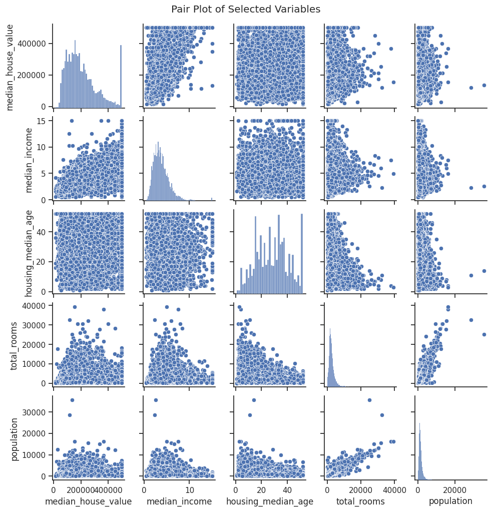

```python
import pandas as pd
import seaborn as sns
import matplotlib.pyplot as plt

# Loading the dataset
housing_data = pd.read_csv('housing.csv')

# Display the first few rows of the dataset to understand its structure
print(housing_data.head())

# Question 3: Explore patterns or trends in the data through exploratory data analysis and visualization
# Create a pair plot to visualize relationships between multiple variables
sns.set(style="ticks")
sns.pairplot(housing_data[['median_house_value', 'median_income', 'housing_median_age', 'total_rooms', 'population']], height=2)
plt.suptitle("Pair Plot of Selected Variables", y=1.02)
plt.show()
```

# Analysis:

A thorough summary of the correlations between the variables in a dataset linked to housing can be obtained from the pair plot. Remarkably, the distributions of median income and median house value are both right-skewed, suggesting that lower-income and lower-priced residences occur more frequently. The more consistent distribution of housing median age, on the other hand, points to a wide variety of housing ages. The distributions of total rooms and population are also right-skew, indicating a predominance of smaller homes and sparserly populated places.The idea that higher income levels typically correspond with more expensive housing is supported by the bivariate scatter plots, which show a strong positive association between median income and median house value. One important lesson from this relationship is that economic status plays a significant role in house affordability. On the other hand, the correlations between population and total rooms and median house value are more nuanced, suggesting a complicated web of interrelated factors influencing housing costs. There are observable trends and anomalies in these charts. Larger houses are generally more expensive, although there is a lot of variation in this relationship, as evidenced by the weakly positive association found between the number of rooms and the median house value. There are clear outliers, such as regions with unusually high population densities compared to room counts, which may indicate densely crowded housing.The matrix emphasises how important median income is in determining the value of a home, but it also shows how a variety of characteristics, including size, age, and population density, have an impact on housing economics. The pair plot proves to be a highly useful instrument for analysing the dynamics of the housing market when these variables are examined together. This highlights the significance of multifactorial analysis in comprehending sectoral trends.

# Question 4: What is the geographical distribution of high-value houses?

Code:

```
   longitude  latitude  housing_median_age  total_rooms  total_bedrooms  \
0    -122.23     37.88                41.0        880.0           129.0
1    -122.22     37.86                21.0       7099.0          1106.0
2    -122.24     37.85                52.0       1467.0           190.0
3    -122.25     37.85                52.0       1274.0           235.0
4    -122.25     37.85                52.0       1627.0           280.0

   population  households  median_income  median_house_value ocean_proximity
0       322.0       126.0         8.3252            452600.0        NEAR BAY
1      2401.0      1138.0         8.3014            358500.0        NEAR BAY
2       496.0       177.0         7.2574            352100.0        NEAR BAY
3       558.0       219.0         5.6431            341300.0        NEAR BAY
4       565.0       259.0         3.8462            342200.0        NEAR BAY
```

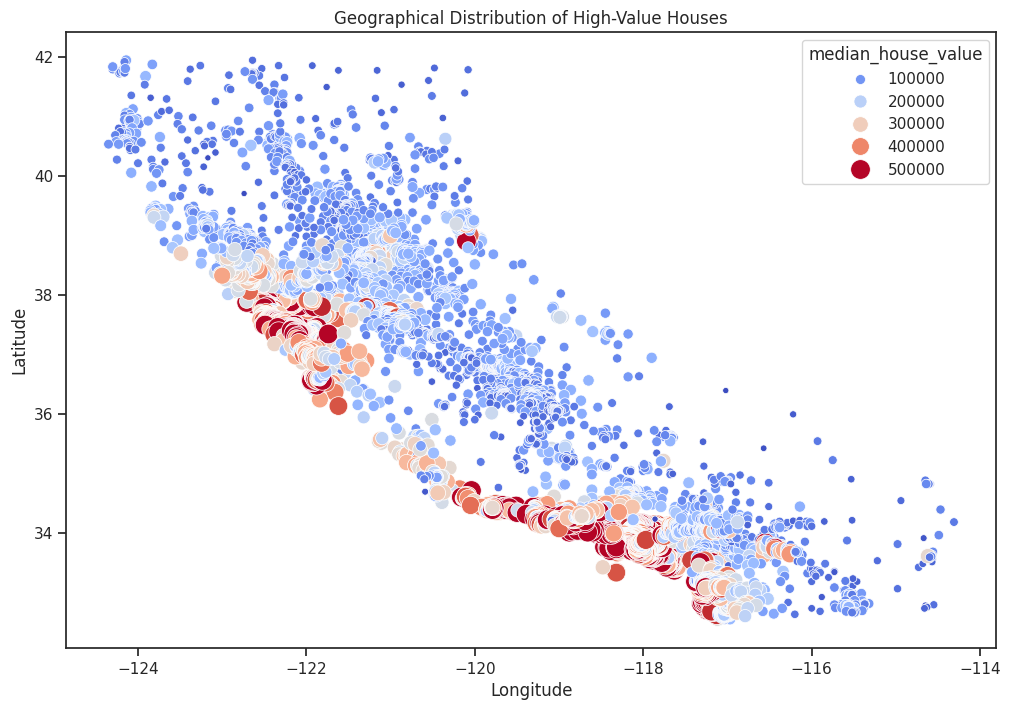

```python
import pandas as pd
import matplotlib.pyplot as plt
import seaborn as sns

housing_data = pd.read_csv('housing.csv')

# Display the first few rows of the dataset to understand its structure
print(housing_data.head())

# Question 4: What is the geographical distribution of high-value houses?
plt.figure(figsize=(12, 8))
sns.scatterplot(x='longitude', y='latitude', hue='median_house_value', palette='coolwarm', size='median_house_value', sizes=(20, 200), data=housing_data)
plt.title('Geographical Distribution of High-Value Houses')
plt.xlabel('Longitude')
plt.ylabel('Latitude')
plt.show()
```